# Report from week 1

Jean Yang

02/09/2020

# Executive summary

Many of us are often concerned about whether we have a good breakfast. In this brief report, we address this question by studying the association between sodium in breakfast cereal from different manufactures. We found that in this dataset, Nabisco and Quaker breakfast cereal tends to have lower sodium content. This information will be useful to consumers who believe that lowering sodium intake will reduce hypertension.

# Introduction and background

This initial data analysis (IDA) report examine the nutrition information from the nutrition labels of breakfast cereals in one supermarket. The manufactures considered here are General Mills (G), Kellogs (K), Nabisco(N), Quaker Oats (Q), Ralston Purina (R), Post (P), American Home Food (A). We input the csv data into R and study the relationship between sodium and the different manufactures using numeric and graphical summaries.

# Results

## The level of sodium

The distribution of sodium for the whole dataset can be best visualize using a histogram. The data looks a bit skew and is likely due to composition from different manufactoring companies.

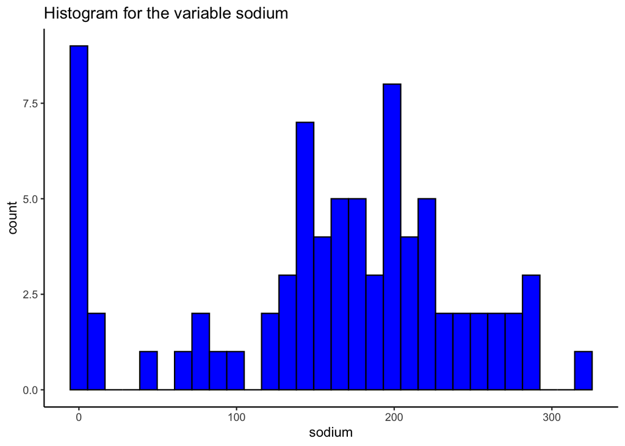

```r
cereal = read.csv("cereal.csv")

## hist(cereal$sodium)

ggplot(cereal, aes(sodium)) + geom_histogram(fill = "blue", color = "black",
    bins = 30) + theme_classic() + labs(title = "Histogram for the variable sodium")
```

We can see from the summary below that the average sodium values is quite different.

```r
aggregate(sodium ~ mfr, data = cereal, FUN = mean)
```

```
##   mfr   sodium
## 1   A   0.0000
## 2   G 200.4545
## 3   K 174.7826
## 4   N  37.5000
## 5   P 146.1111
## 6   Q  92.5000
## 7   R 198.1250
```

```r
## Presentation
val = function(x) {
    round(mean(x, na.rm = TRUE), 1)
}
aggregate(sodium ~ mfr, data = cereal, FUN = val)
```

```
##   mfr sodium
## 1   A    0.0
## 2   G  200.5
## 3   K  174.8
## 4   N   37.5
## 5   P  146.1
## 6   Q   92.5
## 7   R  198.1
```

Code for using an alternative method are:

```
split.sodium <- split(cereal$sodium, cereal$mfr)
round(unlist(lapply(split.sodium, mean)), 1)
```

To capture and compare the different distribution, we use a graphical summary with boxplot. Below demonstrate the constructioin of this using both baseR and ggplot graphics.

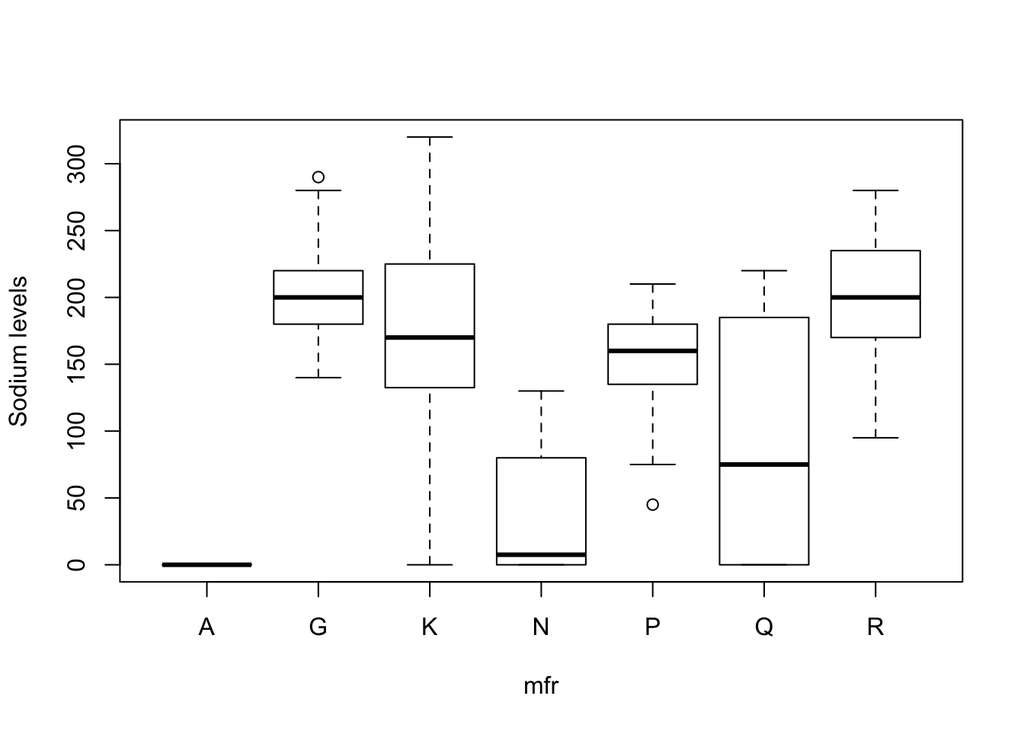

```r
boxplot(cereal$sodium ~ cereal$mfr, xlab = "mfr", ylab = "Sodium levels")
```

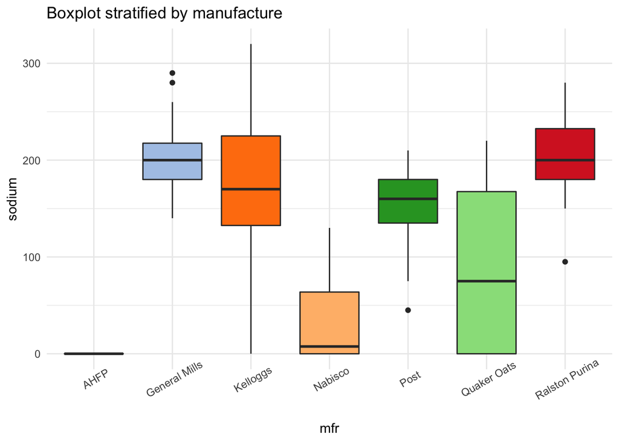

```r
## using ggplot
n = length(levels(cereal$mfr))
col <- tableau_color_pal("Classic 20")(n)
ggplot(cereal, aes(mfr, sodium)) + geom_boxplot(fill = col) + labs(title = "Boxplot stratified by manufacture") +
    scale_x_discrete(labels = c("AHFP", "General Mills", "Kelloggs", "Nabisco",
        "Post", "Quaker Oats", "Ralston Purina")) + theme_minimal() + theme(axis.text.x = element_text(angle = 30))
```

## Extension - shelf

One can also perform a similar investigation between supermarket shelf level and certain nuritian values. For example, it is interesting to see that cereal with high sugar content seems to be located on the middle shelf.

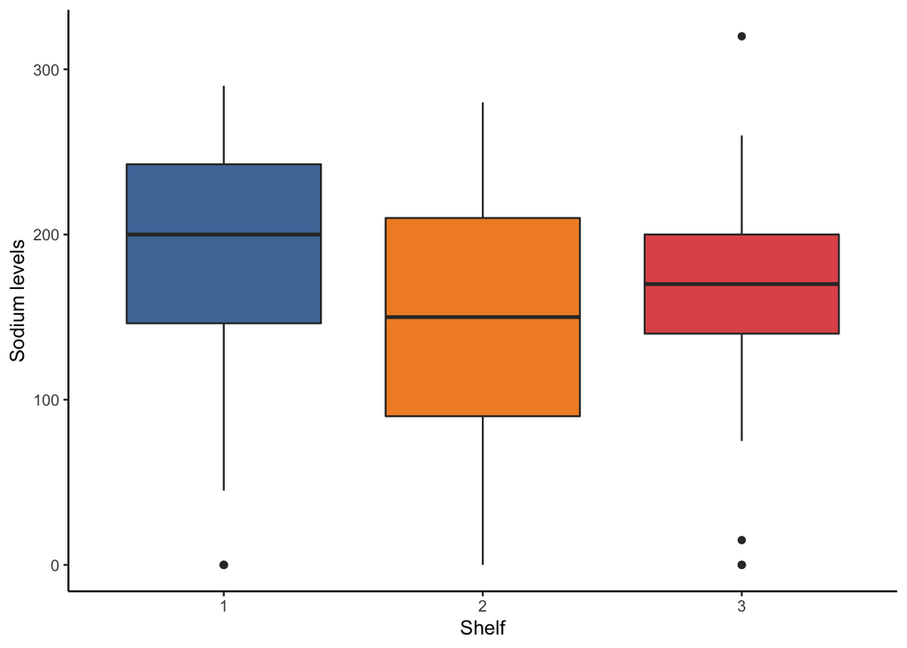

Figure: Boxplot showing the amount of sodium in the cereal stratified by supermarket shelf levels.

```r
n = length(levels(as.factor(cereal$shelf)))
col = tableau_color_pal("Tableau 10")(n)

ggplot(cereal, aes(x = as.factor(shelf), y = sodium)) + geom_boxplot(fill = col) +
    theme_classic() + labs(x = "Shelf", y = "Sodium levels")
```

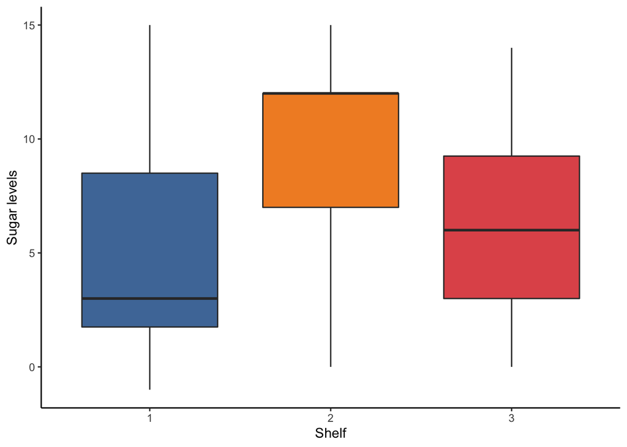

Figure: Boxplot showing the amount of sugar in the cereal stratified by supermarket shelf levels.

```r
ggplot(cereal, aes(as.factor(shelf), sugars)) + geom_boxplot(fill = col) + theme_classic() +
    labs(x = "Shelf", y = "Sugar levels")
```